# Image processing

List of contents:

- Introduction
- Image and video compression
  - Huffman coding
  - JPEG Compression
  - Descrete cosine transform
- Spatial processing
- Image resroration
- Image segmentation
- Geometric PDE's
- Image and video inpainting
- Sparse modeling and compressed sensing
- Medical imaging

# Introduction

This blog provides conceptual practices for main topics in image processing. The content of the blog is examples written in python (jupyter notebook) and clarify the concepts in image processing step by step. The exercises are taken from the coursera course: [Image and Video Processing: From Mars to Hollywood with a Stop at the Hospital](https://www.coursera.org/learn/image-processing/home/welcome).

## Visible light spectrum

The visible spectrum is the portion of the electromagnetic spectrum that is visible to the human eye:

[figure not shown]

## Cameras

Most mid to low end cameras capture the light in a mosaic or [bayer filter sensing](https://patents.google.com/patent/US3971065). Its particular arrangement of color filters is used in most single-chip digital image sensors used in digital cameras, camcorders, and scanners to create a color image.

The filter pattern is 50% green, 25% red and 25% blue, hence is also called BGGR, RGBG,GRGB,or RGGB. For example, a grid as shown in the following figure might be used to capture only one light color per point sensor, and at the end the result is interpolated for all colors and registered as the output image from the camera.

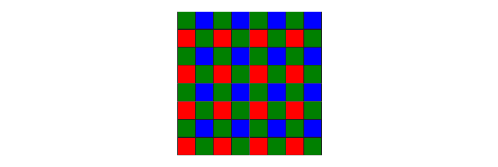

Now let us try that on a picture:

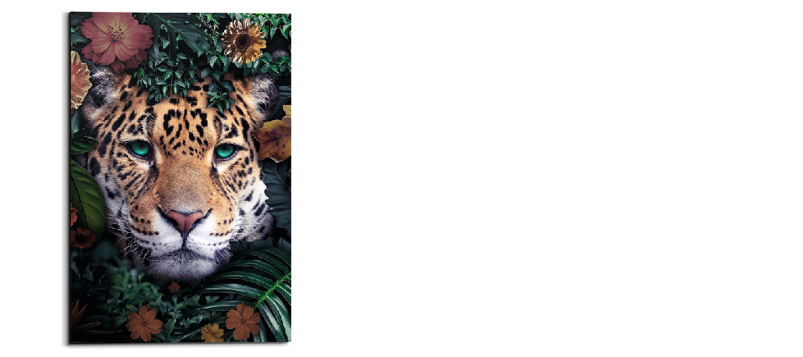

The original image shown above can be split into three channels.

[figure not shown]

If the original image was to be recorded by the mentioned mosaic camera sensor patterns, each of the channels would be set zero on the pixels with no respective sensor for the channel color:

[figure not shown]

And combinig the channels now, this is what the camera sees (right image) versus what the original image would be (left image):

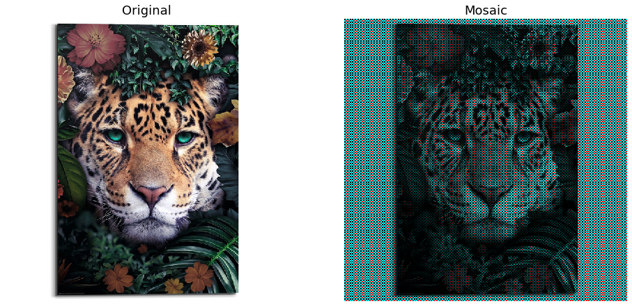

And after interpolating the channels for the missing values, awe get an approximated image, that is the output of the camera:

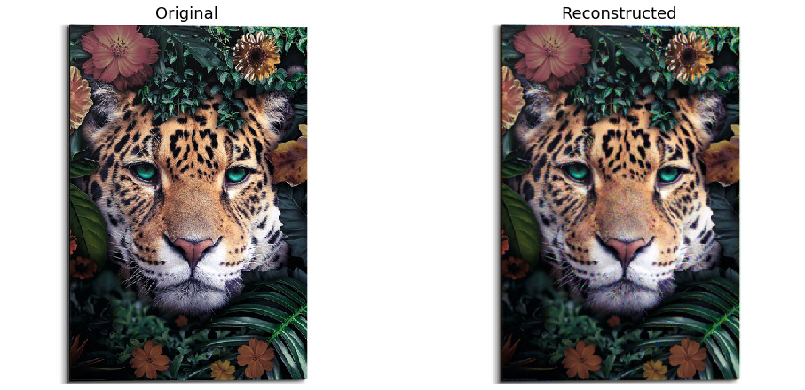

Here the reconsructed picture seems very similar to the original expected. To see the difference, we lower the resolution of the image by 4 in each dimension and redo the procedure. The results show a considerable loss of quality in the reconstruction due to using the mosaic sensoring:

[figure not shown]